# Day 13

## Review

$$\begin{array}{|c|c|}
\hline
\text{Complement} & \text{Union} & \text{Intersection} & \text{Conditional} \\
\hline
P(A^c)=1-P(A) & P(A \text{ or } B) \equiv P(A\cup B) & P(A \text{ and } B) \equiv P(A \cap B) & {P(A\cap B) \over P(B)} \equiv P(A|B)\\
\hline
\end{array}$$

*Addition rule for mutual exclusivity*

Two events $A$ and $B$ are **mutually exclusive** if they do not share any common outcomes

**Typically**:

$$P(A\cup B)=P(A)+P(B)-P(A\cap B)$$

**Given**:

$$A \text{ and } B \Rightarrow \text{ Mutually Exclusive}$$

$$P(A \text{ or } B) = P(A) + P(B)$$

$$P(A \cup B) = P(A) + P(B)$$

*Multiplication Rules*

Def:

$$P(A|B) = \frac{P(A \cap B)}{P(B)},$$

Thus:

$$P(A \cap B) = P(A|B) P(B)$$

Events $A$ and $B$ are independent if the outcome of $A$ does not affect the outcome of $B$ and **vice versa**

$A$ and $B$ are independent if one of the following is true:

$$P(A|B) = P(A)$$

$$P(B|A) = P(B)$$

$$P(A \cap B) = P(A)P(B)$$

**Given:**

$$A \text{ and } B \Rightarrow \text{ Independent}$$

$$P(A \cap B) = P(A)P(B)$$

**Questions?**

## Random Variables

### Random Variable Fundamentals

**Random variable** (shorthand: r.v.):

- A rule for assigning a numerical value to each outcome of a random experiment
- General convention is to use a **capital letter toward the end of the alphabet** to notate these
  - i.e. $X,Y,Z$

> Flip a **fair** coin $3$ **independent** times

**Let** r.v. $X=\{\text{the number of tails observed}\}$

$$S=\{HHH,HHT,HTH,THH,HTT,THT,TTH,TTT\}$$

$$\begin{array}{|c|c|c|c|c|c|}
\hline
\textbf{Flip 1} & \textbf{Flip 2} & \textbf{Flip 3} \\
\hline
\text{H} & \text{H} & \text{H} \\
\hline
\text{H} & \text{H} & \text{T} \\
\hline
\text{H} & \text{T} & \text{H} \\
\hline
\text{T} & \text{H} & \text{H} \\
\hline
\text{H} & \text{T} & \text{T} \\
\hline
\text{T} & \text{H} & \text{T} \\
\hline
\text{T} & \text{T} & \text{H} \\
\hline
\text{T} & \text{T} & \text{T} \\
\hline
\end{array}$$

The r.v. has its own sample space or **support**

**Support:** The set of possible values a r.v. can be

- The support of $X$ is $S_X=\{0,1,2,3\}$

> *Notation clarification* - $S$ generally refers to a sample space, while $S_N$ where $N \rightarrow \text{some random variable}$ refers to **the support of** $N$

Use a lowercase letter to represent the **observed value** of the r.v. so that:

$$x=\text{the value after the experiement has been performed (not random)}$$

$$X=\text{the value before the experiement has been performed (still random)}$$

**Why does this notation distinction matter?**

Statistics is a complex and unique language

- A troublesome language for first time learners
- As you come to understand the language better, the rationale for why we use it begins to make more and more sense

In this case we want to make the following expressions **make sense**:

$$P(X=x)\quad \text{means the probability that r.v.} \ X \ \text{is equal to possible value} \ x$$

$$P(X>x) \quad \text{means the probability that r.v.} \ X \ \text{is greater than possible value} \ x$$

### Random Variable Types

> Random variables are generally separated into two disctinct types: Discrete and Continuous

**Discrete:** The number of **possible values** in the **support** is **finite** or **countably** infinite

**Finite or countably infinite** refers to *integers* or *whole numbers*

**Let** $X=\{\text{The number of students missing from the class roster today}\}$

- The **support** of $X$, $S_X=\{0,1,2,...,40\}$ (assuming my class roster is correct)
- I can’t take on partial values between values $1$ and $2$
- Hypothetically I can’t have more than $40$ students missing on any given day
- This is **Finite and discrete** random variable

**Let** $Y=\{\text{The number of fish in a pond}\}$

- The **support** of $Y$, $S_Y=\{0,1,2,...\}$
- Can I have half a fish? Technically yes. But half a fish isn’t biologically important to count.
- If partial counts **feel arbitrary** then you’re more than likely working with a **discrete** variable
- I can hypothetically have **infinite** fish, but the **realized value** will always be a **whole** number

**Continuous:** The **support** consists of all numbers in an **interval** of the **real number line**

This can be **any interval** or the entire line

- There are **too many numbers to count** (hence: uncountably infinite)

**Let** $Z=\{\text{The change in median housing prices from one year to another}\}$

- The possible values of $Z$ are: $-\infty < Z < \infty$
- We all know this is strictly positive and every increasing, but let’s pretend
- Prices can go down, they can go up, they could just *not change*
- And those prices can be **any** value, partial or whole, negative or positive

**Let** $W=\{\text{The proportion of couples receptive to couples therapy}\}$

- The possible values of $W$ are: $0 \le W \le 1$
- But $W$ can be **anything** in between $0$ and $1$
- Say, $w=0.012843199$ or maybe $w=0.99999991$

> For each random variable, define whether it is **Discrete** or **Continuous** (Bonus: Define the **support** or **possible values** of the random variable)

$$X=\{\text{The number that comes up on a die}\}$$

$$Y=\{\text{The height of a randomly chosen college student}\}$$

$$Z=\{\text{The amount of electricity used to light a randomly chosen classroom}\}$$

$$W=\{\text{The number of siblings a randomly chosen person has}\}$$

$$T=\{\text{The length of time it takes to travel from a random classroom to Calvin hall}\}$$

### Probability Distributions

The form of a r.v.’s **probability distribution** depends on whether it is **continuous** or **discrete**

For a **discrete random variable** the probability distribution is often a *list* of all possible values the r.v. can take and their corresponding *probabilities of occurrence*

**Discrete probability distributions** satisfy the following two properties:

$$i. \quad 0 \le P(X=x) \le 1$$

$$ii. \quad \sum_x P(X=x)=1$$

**Let** $X = \{\text{the number of customers in a line at a supermarket express checkout counter}\}$. The probability distribution of $X$ is given as follows:

$$\begin{array}{|c|c|c|c|c|c|c|}
\hline
x & 0 & 1 & 2 & 3 & 4 & 5 \\
\hline
P(X = x) & 0.4 & 0.2 & 0.15 & 0.1 & 0.1 & 0.05 \\
\hline
\end{array}$$

1. Is this a legitimate probability distribution?
2. Find the probability that there is no customer in a line at the express checkout.
3. Find the probability that there is at least one customer in a line at the express checkout.
4. $P(2 < X \le 5)$

For a **continuous random variable** probabilities are determined via a **probability density function** or **pdf**

- To actually dig into this discussion properly, we need to use **Calculus**
- The remainder of today will just focus on discrete concepts

We can draw a **histogram** so that the area of each bar above a given possible value of a r.v. is equal to it’s **probability of occurrence**

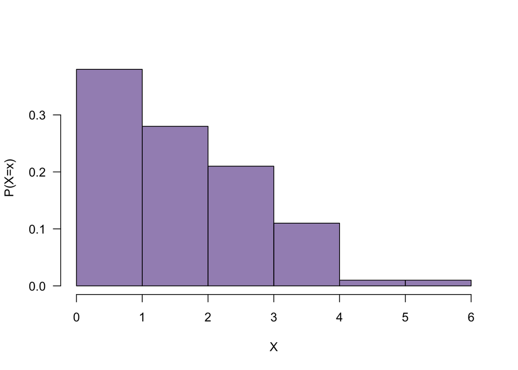

As with datasets, probability distributions can have **shape** and **measures of center** as well as **spread**

- What is the shape of this probability distribution?

### Discrete r.v. Mean (Expectation)

Mathematicians (and Statisticians) prefer deriving values and writing equations in more **general forms**

- Not because we like to confuse people, but because we’re lazy

> We want to develop a general form for a measure of center and variability for a discrete probability distribution

Consider the probability distribution of $X$ to be a **population**

- Numerical values that we calculate from a probability distribution are called **parameters**
- We would notate the **mean** of a **population** with $\mu$
  - We can use the same notation for the mean of a **probability distribution**

Given several random variables to consider, we can denote the mean of r.v. $X$ as:

$$\mu X \quad \textbf{or} \quad \mathbb{E}(X)$$

For a **discrete probability distribution** of r.v. $X$, the mean is given by:

$$\mathbb{E}(X)=\mu=\sum_x xP(X=x)$$

- We call this “the weighted sum of all probabilities of $x$”

$X=\{\text{number of customers in a line at the express checkout counter}\}$

$$\begin{array}{|c|c|c|c|c|c|c|}
\hline
x & 0 & 1 & 2 & 3 & 4 & 5 \\
\hline
P(X = x) & 0.4 & 0.2 & 0.15 & 0.1 & 0.1 & 0.05 \\
\hline
\end{array}$$

Recalling our definition of the mean of a probability distribution for a **discrete** r.v.

$$\mathbb{E}(X)=\mu=\sum_x xP(X=x)$$

We get:

$$\mu_X=\sum_x xP(X=x)$$
$$=0(0.4)+1(0.2)+2(0.15)+3(0.1)+4(0.1)+5(0.05)=1.45$$

So we would say: “over time we **expect** to have $1.45$ customers in a line at the express checkout counter”

### Interpretation of the Mean of a r.v.

We’ve previously discussed how the **mean** of a dataset is it’s balance point (fulcrum)

- Shockingly, the *exact same* interpretation applies

You can also consider $\mu$ to be the “average in the long run”

> Using the Law of Large Numbers:
- As we produce more observations and take their averages ($\bar{x}$)
- We should approach/converge on the value of $\mu$

### Variance of a Discrete Probability Distribution

As discussed, probability distributions have spread, spread we can *measure*

Denoting the **variance** of discrete r.v. $X$:

$$\sigma^2_X \quad \text{or} \quad \text{Var}(X) \quad \text{or} \quad \mathbb{V}X$$

The general formula for the variance of r.v. $X$:

$$\sigma^2=\sum_x (x-\mu)^2 P(X=x)$$

$X=\{\text{number of customers in a line at the express checkout counter}\}$

$$\begin{array}{|c|c|c|c|c|c|c|}
\hline
x & 0 & 1 & 2 & 3 & 4 & 5 \\
\hline
P(X = x) & 0.4 & 0.2 & 0.15 & 0.1 & 0.1 & 0.05 \\
\hline
\end{array}$$

Recalling our definition of **variance**:

$$\sigma^2=\sum_x (x-\mu)^2 P(X=x)$$

We get:

$$\sigma^2_X=\sum_x (x-\mu)^2 P(X=x), \ \ \ \text{recall} \ \mu=1.45$$

$$=(0-1.45)^2(0.4)+(1-1.45)^2(0.2)+(2-1.45)^2(0.15)+(3-1.45)^2(0.1)+(4-1.45)^2(0.1)+(5-1.45)^2(0.05)$$

$$=2.4475$$

For **standard deviation**, defined loosely as the “average” distance from $\mu$ in the probability distribution:

$$\sigma=\sqrt{\sigma^2}$$

So:

$$\sigma_X=\sqrt{2.4475}\approx 1.564$$

> Given the following probability distribution of *discrete* r.v. $X$:

$$\begin{array}{|c|c|c|c|c|}
\hline
x & 0 & 1 & 2 & 3 \\
\hline
P(X = x) & 0.3 & 0.4 & 0.2 & 0.1 \\
\hline
\end{array}$$

1. Is this a proper probability distribution? Why or why not?
2. Find $\mathbb{E}(X)$
3. Find $Var(X)$
4. Find $\sigma_X$

> Given the **probability histogram** for r.v. $X$:

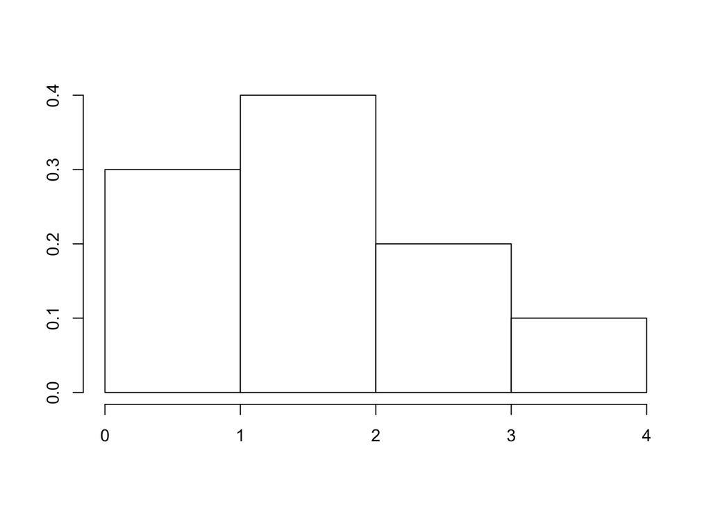

- What is it’s shape?